# Exploratory Data Analysis Dados Saúde 2018 Bruno Zamberlan

**Contexto:** O objetivo é demonstrar as práticas de EDA de Tukey aplicados aos dados sobre minha saúde coletados no ano de 2018. Acesse o link para uma [Visão Geral EDA](https://pt.wikipedia.org/wiki/An%C3%A1lise_explorat%C3%B3ria_de_dados). Além disso, recomendo [Aplicando os conceitos de EDA com Python](https://towardsdatascience.com/exploratory-data-analysis-8fc1cb20fd15)

**Objetivo:** Explorar dados sobre minha saúde em 2018 visando melhorar meus hábitos para 2019

**Problema:** Variáveis: *Peso ao final da semana* e *Quantidade de sessões de exercícios na semana*. Para fins didáticos, considerei o ano com 51 semanas completas. São 51 observações que representam as semanas do ano de 2018.

*Antes de iniciar, dividi o problema em 4 partes*

#### PASSO-A-PASSO

##### 1) Importar

##### 2) Limpar

##### 3) Explorar (AQUI QUE FOCAMOS NAS TÉCNICAS DE E.D.A)

##### 4) Gerar Insights

## Passo 1: IMPORTAR

Procurei deixar os dados mais próximos de serem trabalhados utilizando excel e salvando os dados no formato .CSV

```r
saude_2018 <- read.csv(file.choose(), header = T, sep = ";")
```

### Para facilitar a localização do arquivo e não precisar digitar o caminho completo, utilize a opção **file.choose()**. Se preferir, é só colocar a localização do arquivo como parâmetro inicial

### Após a importação, utilizo o comando **head()** para verificar como ficou a estrutura do arquivo

|  | ï..peso | qtde_exerc |
| --- | --- | --- |
| 1 | 94,50 | 3 |
| 2 | 93,90 | 5 |
| 3 | 92,60 | 1 |
| 4 | 92,20 | 2 |
| 5 | 90,80 | 1 |
| 6 | 90,30 | 2 |

## Passo 2: LIMPAR

### Sugiro começar pelo ajuste do nome das variáveis. Nesse caso, vou utilizar o **colnames()** passando um vetor com os dois nomes de variáveis que quero utilizar **peso** E **qtde_exerc**

```r
colnames(saude_2018) <- c("peso", "qtde_exerc")
```

### Para verificar a efetividade, utilizo novamente o **head()**

|  | peso | qtde_exerc |
| --- | --- | --- |
| 1 | 94,50 | 3 |
| 2 | 93,90 | 5 |
| 3 | 92,60 | 1 |
| 4 | 92,20 | 2 |
| 5 | 90,80 | 1 |
| 6 | 90,30 | 2 |

## Obs: Se você executar somente o **sub(“,”, “.”, saude_2018$peso)** você terá o resultado na tela, mas a atribuição do resultado na variável não ocorrerá. Por isso, é utilizado o símbolo ** <- **

### Para verificar a efetividade da substituição, utilizo novamente o comando **head()**

|  | peso | qtde_exerc |
| --- | --- | --- |
| 1 | 94.50 | 3 |
| 2 | 93.90 | 5 |
| 3 | 92.60 | 1 |
| 4 | 92.20 | 2 |
| 5 | 90.80 | 1 |
| 6 | 90.30 | 2 |

Por fim, utilizo o comando **str()** para verificar como ficaram os tipos de dados

```r
str(saude_2018)
```

```
'data.frame':   51 obs. of  2 variables:
 $ peso      : chr  "94.50" "93.90" "92.60" "92.20" ...
 $ qtde_exerc: int  3 5 1 2 1 2 3 0 0 1 ...
```

### Verificando a estrutura, percebemos que será necessário converter o tipo da variável **$peso** para **double** visto que temos um número com vírgula

```r
saude_2018$peso <- as.double(saude_2018$peso)
```

|  | peso | qtde_exerc |
| --- | --- | --- |
| 1 | 94.5 | 3 |
| 2 | 93.9 | 5 |
| 3 | 92.6 | 1 |
| 4 | 92.2 | 2 |
| 5 | 90.8 | 1 |
| 6 | 90.3 | 2 |

### Para facilitar a análise, nomearei as linhas também seguindo uma sequência lógica semana1, semana2

|  | peso | qtde_exerc |
| --- | --- | --- |
| semana 1 | 94.5 | 3 |
| semana 2 | 93.9 | 5 |
| semana 3 | 92.6 | 1 |
| semana 4 | 92.2 | 2 |
| semana 5 | 90.8 | 1 |
| semana 6 | 90.3 | 2 |

## A partir desse momento, o dataframe está pronto para ser utilizado!!!

### Para ter uma visão geral dos dados, utilizarei o comando **summary()**

```r
summary(saude_2018$peso)
```

```
   Min. 1st Qu.  Median    Mean 3rd Qu.    Max.
  84.30   85.08   86.80   87.29   88.85   94.50
```

```r
summary(saude_2018$qtde_exerc)
```

```
   Min. 1st Qu.  Median    Mean 3rd Qu.    Max.
  0.000   1.000   2.000   1.843   2.500   5.000
```

## Passo 3: Explorar

### Para ter uma visão dos dados, podemos enfatizar nossa análise em 3 aspectos

### **1) Localização dos dados:** Tentar localizar um valor que represente a variável explorada

### **2) Variabilidade dos dados:** Refere-se a dispersão dos dados identificando o que é variabilidade como “obra do ocaso” e o que tem uma fonte real de variação

### **3) Distribuição dos dados:** Combina os 2 aspectos explorados anteriormente de forma visual

### Localização de dados: Recomendo utilizar 3 medidas: Média, Média Ajustada e Mediana.

Dica: Utilizar a média como “representante” dos seus dados pode esconder os outliers (valores extremos). Por isso, recomendo comparar as 3 medidas, veja só:

```r
paste("A média da variável peso é", mean(saude_2018$peso))
```

```
[1] "A média da variável peso é 87.2901960784314"
```

```r
paste("A média ajustada da variável peso é", mean(saude_2018$peso, trim = 0.1))
```

```
[1] "A média ajustada da variável peso é 86.9585365853658"
```

```r
paste("A mediana da variável é", median(saude_2018$peso))
```

```
[1] "A mediana da variável é 86.8"
```

## Observar que para fazer a média ajustada, utilizei o parâmetro **trim** que remove os 10%(0.1) extremos!!!

```r
paste("A média da variável quantidade de exercícios físicos é", mean(saude_2018$qtde_exerc))
```

```
[1] "A média da variável quantidade de exercícios físicos é 1.84313725490196"
```

```r
paste("A média ajustada da variável quantidade de exercícios físicos é", mean(saude_2018$qtde_exerc, trim = 0.1))
```

```
[1] "A média ajustada da variável quantidade de exercícios físicos é 1.80487804878049"
```

```r
paste("A mediana da variável quantidade de exercícios físicos é", median(saude_2018$qtde_exerc))
```

```
[1] "A mediana da variável quantidade de exercícios físicos é 2"
```

### Variabilidade: Recomendo utilizar 2 medidas: desvio padrão e quartis (não sensíveis aos outilers)

```r
paste("O desvio padrão para a variável peso é", sd(saude_2018$peso))
```

```
[1] "O desvio padrão para a variável peso é 2.63359107698677"
```

```r
print("Os 4 principais quartis da distribuição da variável peso são:")
```

```
[1] "Os 4 principais quartis da distribuição da variável peso são:"
```

```r
quantile(saude_2018$peso)
```

```
    0%    25%    50%    75%   100%
84.300 85.075 86.800 88.850 94.500
```

## Os quartis para a variável peso significam, basicamente, as 4 faixas em que o meu peso variou durante o ano.

```r
paste("O desvio padrão para a variável quantidade de exercícios é", sd(saude_2018$qtde_exerc))
```

```
[1] "O desvio padrão para a variável quantidade de exercícios é 1.17256213514863"
```

```r
print("Os 4 principais quartis da distribuição da variável quantidade de exercícios é:")
```

```
[1] "Os 4 principais quartis da distribuição da variável quantidade de exercícios é:"
```

```r
quantile(saude_2018$qtde_exerc)
```

```
  0%  25%  50%  75% 100%
 0.0  1.0  2.0  2.5  5.0
```

```r
quantile(saude_2018$qtde_exerc, p = c(0.1, 0.30, .60, 0.96))
```

```
10% 30% 60% 96%
  0   1   2   4
```

## No caso, os quartis ficaram mais adequados a realidade: é razoável dizer que, quando realizei exercícios físicos na semana, variou numa frequência de 1 a 4 vezes. O Quartil 10% mostra que em algumas semanas eu não fiz nenhum exercício físico.

### Distribuição dos dados: Recomendo analisar os histogramas e os boxplots

## Boxplots

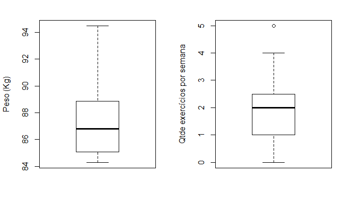

```r
par(mfrow=c(1,2))
boxplot(saude_2018$peso, ylab = "Peso (Kg)")
boxplot(saude_2018$qtde_exerc, ylab = "Qtde exercícios por semana")
```

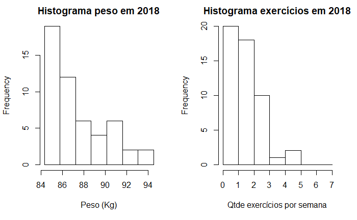

```r
par(mfrow = c(1,2))
quebras_peso <- seq(from=min(saude_2018$peso), to=max(saude_2018$peso), length=8)
quebras_qtde_exerc <- seq(from=min(saude_2018$qtde_exerc, to=max(saude_2018$qtde_exerc)), length=8)
hist(saude_2018$peso, xlab = "Peso (Kg)", main = "Histograma peso em 2018", breaks = quebras_peso)
hist(saude_2018$qtde_exerc, main = "Histograma exercícios em 2018", xlab = "Qtde exercícios por semana", breaks = quebras_qtde_exerc)
```

### 3) Em 10 semanas, consegui fazer 3 exercícios físicos

## Passo 4: GERAR INSIGHTS

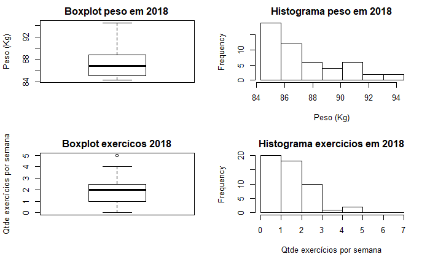

## Insights:

# Meu peso em 2018

### * Em + de 15 semanas (cerca de 36% do ano), o peso ficou entre 84kg e 86kg o que demonstra que foi a menor faixa de peso que consegui manter durante o ano

# Meus hábitos de exercícios físicos em 2018

### * Em pelo menos 10 semanas (cerca de 20% do ano), consegui fazer exercício físico 3x

### * Em alguma das semanas, consegui fazer 4x exercício físico